# Examples for FMAT code

Yuqing Jin 金昱清

2024-12-13

## 简介

本部分代码主要介绍Fill-Mask Association Test(FMAT)在R中的实现  
**Reference:**  
Bao, H-W-S. (2024). The Fill-Mask Association Test(FMAT): Measuring propositions in Natural Language. *Journal of Personality and Social Psychology*, *127*(3), 537–561. https://doi.org/10.1037/pspa0000396  
Bao, H.-W.-S. (2023). FMAT: The Fill-Mask Association Test. https://CRAN.R-project.org/package=FMAT

## 1. 环境配置与BERT模型下载

**第一步**：安装Python的Anaconda编译器并进行环境配置

[figure not shown]

**第二步**：配置R, Python, Anaconda的环境变量  
具体操作方式可见：https://blog.csdn.net/wangpaiblog/article/details/113532591  
**第三步**：在”Rstuio–Tools–Global Options”选择Anaconda作为Python编译器

[figure not shown]

**第四步**：“win+r”打开cmd，激活Anaconda环境

```bash
conda list ##查看anaconda环境，一般有base
conda activate base ##激活anaconda环境，即可安装指定Python包
```

输入下方代码，安装指定版本的python包

```bash
pip install transformers==4.40.2 torch==2.2.1 huggingface-hub==0.20.3
```

**第五步**：在Rstudio中安装BERT模型

```r
install.packages("FMAT")
library(FMAT)

##选择要下载的BERT模型，可根据实际研究需求更改
models = c("bert-base-uncased",
           "bert-base-cased",
           "bert-large-uncased",
           "bert-large-cased",
           "distilbert-base-uncased",
           "distilbert-base-cased",
           "albert-base-v1",
           "albert-base-v2",
           "roberta-base",
           "distilroberta-base",
           "vinai/bertweet-base",
           "vinai/bertweet-large")

##BERT模型下载，下载路径为C：/Users/%Username%/.cache/huggingface
BERT_download(models)
```

BERT模型下载速度可能很慢，可以通过更改R镜像的方式加速：  
RStudio–Tools–Global Options–Packages–Change 选择中国以外的镜像即可  
如仍然较慢，可以选择科学上网

[figure not shown]

## 2. FMAT示例：只用4个基础BERT模型

安装并加载必要的R包

```r
#Pacman
if (!requireNamespace('pacman', quietly = TRUE)) {
    install.packages('pacman')
}

#Core
pacman::p_load(FMAT)

#General
pacman::p_load(bruceR,tidyverse)

#Specific
pacman::p_load(irr,nlme,knitr,ggrepel,zoo,see,cowplot,sjPlot)
```

数据预处理

```r
##数据预处理
words <- import("../Data/FMAT_words/words.csv")

process_column <- function(column){
  column <- column[column != ""]
  return(column)
}

subjects <- process_column(words$Subjects)
A1_inter <- process_column(words$A1_inter) %>%
  tolower()
A2_bor <- process_column(words$A2_bor) %>%
  tolower()
A3_useful <- process_column(words$A3_useful) %>%
  tolower()
A4_useless <- process_column(words$A4_useless) %>%
  tolower()

words <- list(subjects=subjects,
              A1_int = A1_inter,
              A2_bor = A2_bor,
              A3_usef = A3_useful,
              A4_usel = A4_useless)

remove(A1_inter,A2_bor,A3_useful,A4_useless,subjects)
```

FMAT的代码，设计两个不同的命题：  
Query 1: {TARGET} is [MASK].  
Query 2: Most people think {TARGET} is [MASK].

```r
#Query for interesting/boring
Query_Int = FMAT_query_bind(
  FMAT_query("{TARGET} is [MASK].",
             MASK = .(interesting = words$A1_int, boring = words$A2_bor),
             TARGET = .(subject = words$subjects)
  ),
  FMAT_query("Most people think {TARGET} is [MASK].",
             MASK = .(interesting = words$A1_int, boring = words$A2_bor),
             TARGET = .(subject = words$subjects)
  )
)

#Query for useful/useless
Query_Use = FMAT_query_bind(
  FMAT_query("{TARGET} is [MASK].",
             MASK = .(useful = words$A3_usef, useless = words$A4_usel),
             TARGET = .(subject = words$subjects)
  ),
  FMAT_query("Most people think {TARGET} is [MASK].",
             MASK = .(useful = words$A3_usef, useless = words$A4_usel),
             TARGET = .(subject = words$subjects)
  )
)
```

运行BERT模型进行FMAT分析

```r
Result_Int_4mod = FMAT_run(models[1:4], Query_Int)
Result_Use_4mod = FMAT_run(models[1:4], Query_Use)

Sum_Int_4mod = summary(Result_Int_4mod,
                       target.pair=FALSE)[,.(model,query,T_word,M_word,LPR)]
Sum_Use_4mod = summary(Result_Use_4mod,
                       target.pair=FALSE)[,.(model,query,T_word,M_word,LPR)]
```

进行ICC计算

```r
#ICC计算
LPR_reliability(Sum_Int_4mod, item="query") %>% kable(digits=2)
```

| n.obs | k.items | alpha |
| --- | --- | --- |
| 108 | 2 | 0.73 |

```r
LPR_reliability(Sum_Int_4mod, item="query", by="model") %>% kable(digits=2)
```

| model | n.obs | k.items | alpha |
| --- | --- | --- | --- |
| bert-base-uncased | 27 | 2 | 0.42 |
| bert-base-cased | 27 | 2 | 0.41 |
| bert-large-uncased | 27 | 2 | 0.46 |
| bert-large-cased | 27 | 2 | 0.15 |

```r
LPR_reliability(Sum_Use_4mod, item="query") %>% kable(digits=2)
```

| n.obs | k.items | alpha |
| --- | --- | --- |
| 108 | 2 | 0.57 |

```r
LPR_reliability(Sum_Use_4mod, item="query", by="model") %>% kable(digits=2)
```

| model | n.obs | k.items | alpha |
| --- | --- | --- | --- |
| bert-base-uncased | 27 | 2 | 0.63 |
| bert-base-cased | 27 | 2 | 0.61 |
| bert-large-uncased | 27 | 2 | 0.51 |
| bert-large-cased | 27 | 2 | 0.47 |

可以绘图

命题一的结果：{TARGET} is [MASK].

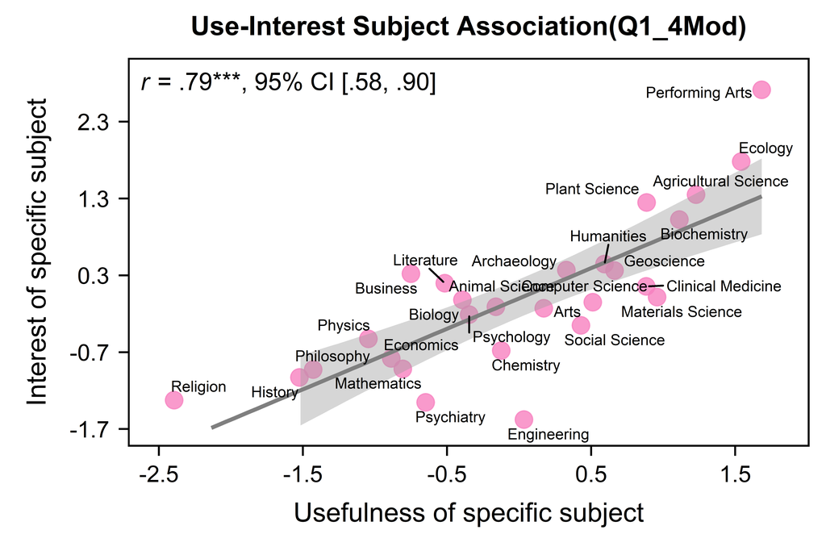

命题二的结果：Most people think {TARGET} is [MASK].

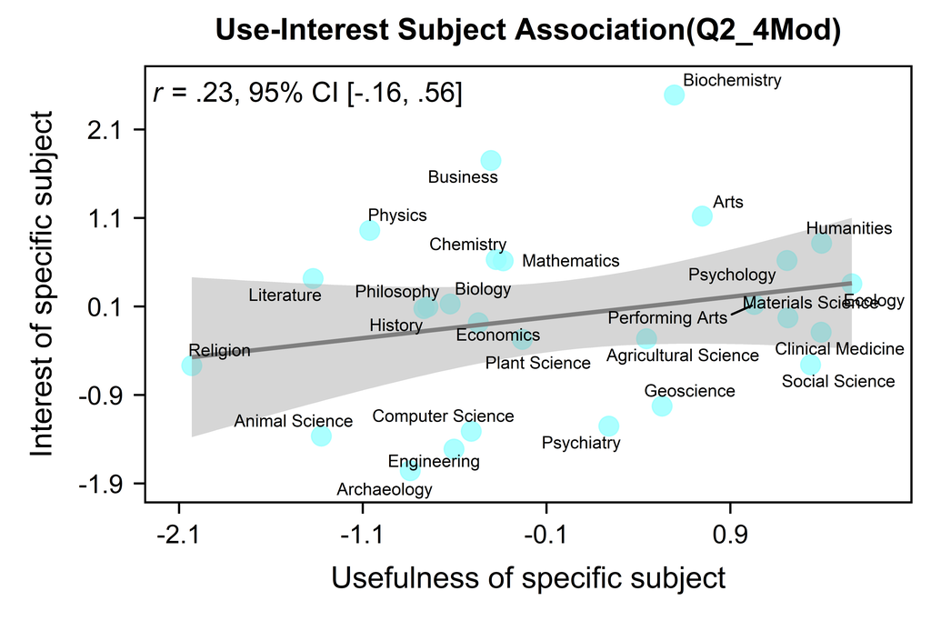

## 3. FMAT示例：使用12个BERT模型

前面都一样我们直接来看结果

```r
#ICC计算
LPR_reliability(Sum_Int_12mod, item="query") %>% kable(digits=2)
```

| n.obs | k.items | alpha |
| --- | --- | --- |
| 324 | 2 | 0.79 |

```r
LPR_reliability(Sum_Int_12mod, item="query", by="model") %>% kable(digits=2)
```

| model | n.obs | k.items | alpha |
| --- | --- | --- | --- |
| bert-base-uncased | 27 | 2 | 0.42 |
| bert-base-cased | 27 | 2 | 0.41 |
| bert-large-uncased | 27 | 2 | 0.46 |
| bert-large-cased | 27 | 2 | 0.15 |
| distilbert-base-uncased | 27 | 2 | 0.72 |
| distilbert-base-cased | 27 | 2 | 0.69 |
| albert-base-v1 | 27 | 2 | 0.62 |
| albert-base-v2 | 27 | 2 | 0.87 |
| roberta-base | 27 | 2 | 0.35 |
| distilroberta-base | 27 | 2 | 0.01 |
| vinai/bertweet-base | 27 | 2 | 0.34 |
| vinai/bertweet-large | 27 | 2 | 0.49 |

```r
LPR_reliability(Sum_Use_12mod, item="query") %>% kable(digits=2)
```

| n.obs | k.items | alpha |
| --- | --- | --- |
| 324 | 2 | 0.62 |

```r
LPR_reliability(Sum_Use_12mod, item="query", by="model") %>% kable(digits=2)
```

| model | n.obs | k.items | alpha |
| --- | --- | --- | --- |
| bert-base-uncased | 27 | 2 | 0.63 |
| bert-base-cased | 27 | 2 | 0.61 |
| bert-large-uncased | 27 | 2 | 0.51 |
| bert-large-cased | 27 | 2 | 0.47 |
| distilbert-base-uncased | 27 | 2 | 0.77 |
| distilbert-base-cased | 27 | 2 | 0.70 |
| albert-base-v1 | 27 | 2 | 0.87 |
| albert-base-v2 | 27 | 2 | 0.64 |
| roberta-base | 27 | 2 | 0.32 |
| distilroberta-base | 27 | 2 | -0.97 |
| vinai/bertweet-base | 27 | 2 | 0.26 |
| vinai/bertweet-large | 27 | 2 | 0.44 |

命题一的结果：{TARGET} is [MASK]

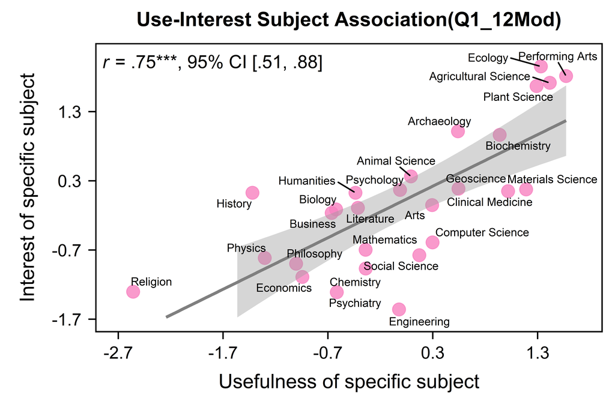

命题二的结果：Most people think {TARGET} is [MASK].

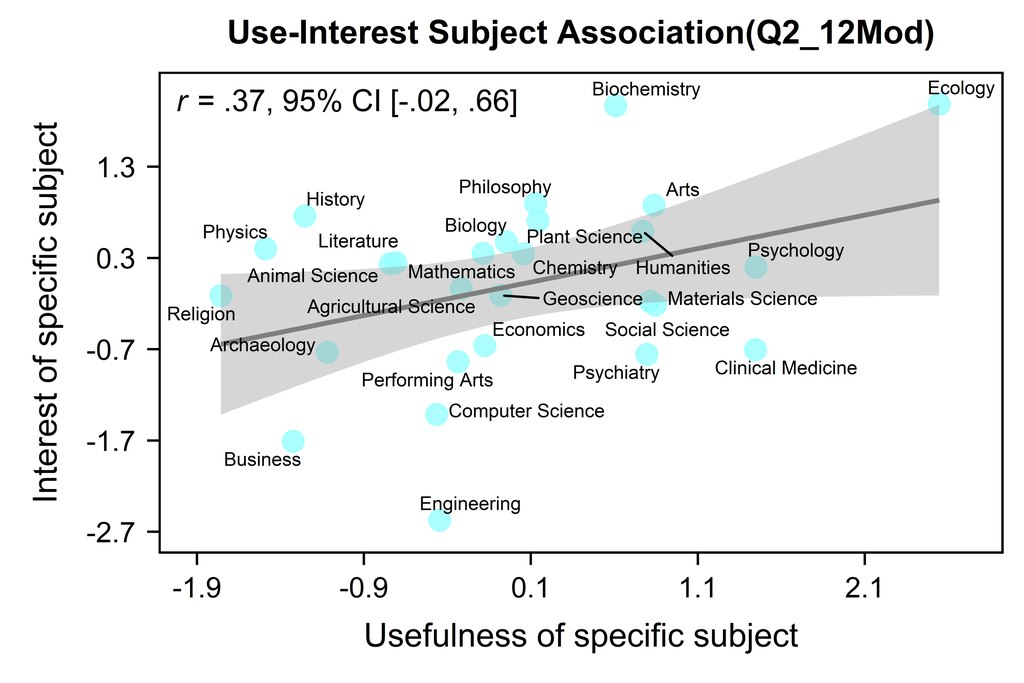

我们也可以把两个命题的数据合并来看

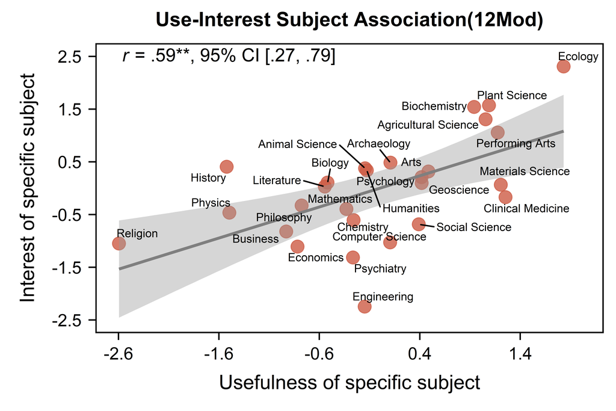

## 4. 注意事项

**关于BERT模型的选取**  
1. 根据研究的主题确定使用的BERT模型  
2. 使用的BERT模型越多越好，12个是基线

**关于命题的设计**  
1. 默认命题带有前提：“Most people from the corpus think”，避免**嵌套式命题**  
2. 命题最好选择**客观**的事实(e.g. 职位、工作、性别)而非**抽象**的概念(e.g. 有趣/无聊)

**关于MASK词的选择**  
1. 比较生僻(Monotonous)以及词根复合词(Unhelpful,ineffective)不建议作为MASK词，BERT模型本身识别不了  
2. 使用GPT或字典拓展MASK词库，可以提升研究结果的稳定性  
上述代码为学习FMAT后的尝试，如在使用过程中有任何疑问或错误，欢迎提出与指正！  
**Reference:**  
Bao, H-W-S. (2024). The Fill-Mask Association Test(FMAT): Measuring propositions in Natural Language. *Journal of Personality and Social Psychology*, *127*(3), 537–561. https://doi.org/10.1037/pspa0000396  
Bao, H.-W.-S. (2023). FMAT: The Fill-Mask Association Test. https://CRAN.R-project.org/package=FMAT